# Homelessness 1

Harrison Linder

2024-08-22

## data sources

I am using two main data sources. The first is PIT and HIC count data from HUD. This includes statistics collected during the annual Point in Time (PIT) counts and the annual counts of shelter and permanent housing available in each Continuum of Care (CoC). The specific PIT data table used was created in excel by me using excel data from HUD’s website. The second data sources comes from California’s HDIS data and is directly queried from their website. I look at 5 years of data from 2019 to 2023. At the time of this analysis, the 2023 data was the latest available.

```r
PITdata <- read_excel("PIT count data 2019 to 2023.xlsx")
HDISdata <- read.csv("https://data.ca.gov/dataset/c7ed1ae4-4f93-4fc7-b603-3cd07a55d862/resource/b1a5ae24-5842-425c-b56c-aa90f8f1c767/download/homelessness-count-by-age.csv")
```

## Cleaning and transforming data

creating new variables: totals for permanent housing

```r
pittotals <- PITdata %>%
    group_by(year) %>%
    summarise(`Overall Homeless` = sum(`Overall Homeless`),
              `Sheltered Total Homeless` = sum(`Sheltered Total Homeless`),
              `Unsheltered Homeless` = sum(`Unsheltered Homeless`),
              `Total Year-Round Beds (ES, TH, SH)` = sum(`Total Year-Round Beds (ES, TH, SH)`),
              `Total Year-Round Beds (RRH)` = sum(`Total Year-Round Beds (RRH)`),
              `Total Year-Round Beds (PSH)` = sum(`Total Year-Round Beds (PSH)`),
              `Total Year-Round Beds (OPH)` = sum(`Total Year-Round Beds (OPH)`)
              ) %>%
            ungroup()

PITdata <- bind_rows(PITdata, pittotals)

PITdata <- PITdata %>%
    mutate(`CoC Name` = ifelse(is.na(`CoC Name`), "California", `CoC Name`), `CoC Number` = ifelse(is.na(`CoC Number`), "All", `CoC Number`))
```

the `PITdata` is already ready to use, but I want to simplify my HDIS data by combining all the age tranches into a total count. I will also match the years in the `PITdata` so that I can join the two data sets together.

```r
HDISdata$EXPERIENCING_HOMELESSNESS_CNT <- as.numeric(HDISdata$EXPERIENCING_HOMELESSNESS_CNT) # making the count a numeric vector instead of a character vector
HDISdata <-HDISdata %>%
    mutate(EXPERIENCING_HOMELESSNESS_CNT = ifelse(is.na(EXPERIENCING_HOMELESSNESS_CNT),0, EXPERIENCING_HOMELESSNESS_CNT))

HDISyearlytotals <- HDISdata %>%
    group_by(CALENDAR_YEAR, LOCATION_ID, LOCATION) %>%
    summarise(hdistotal_count = sum(EXPERIENCING_HOMELESSNESS_CNT))
```

joining hdis data with pit data

```r
PITdata <- PITdata %>%
    rename( LOCATION_ID = `CoC Number`)

HDISyearlytotals <- HDISyearlytotals %>%
    rename(year = CALENDAR_YEAR)

PITandHDIS <- PITdata %>%
    left_join(HDISyearlytotals[,c("year", "LOCATION_ID", "hdistotal_count")], by = c("year", "LOCATION_ID"))

PITandHDIS <- PITandHDIS %>%
    select(-starts_with("..."))

PITandHDIS <- PITandHDIS %>%
    select(-`Count Types`)

PITandHDIS <- PITandHDIS %>%
    mutate(total_permanent_housing = `Total Year-Round Beds (OPH)` + `Total Year-Round Beds (RRH)` + `Total Year-Round Beds (PSH)`)


PITandHDIS <- PITandHDIS %>%
    rename(pittotal_count = `Overall Homeless`)
```

making long data for better plots

```r
longPITandHDIS <- melt(PITandHDIS,
id.vars = c("year", "LOCATION_ID", "CoC Name"),
measure.vars = c("hdistotal_count","pittotal_count", "Unsheltered Homeless", "Sheltered Total Homeless",  "Total Year-Round Beds (ES, TH, SH)", "total_permanent_housing"),
variable.name = "Count_Type",
value.name = "Count")
```

## Graphing counts over time

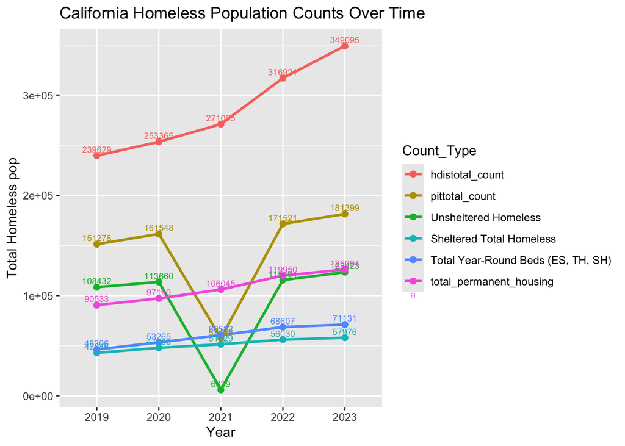

```r
ggplot(longPITandHDIS[longPITandHDIS$LOCATION_ID == "All",], aes(x = factor(year), y = Count, color = Count_Type, group = Count_Type)) +
  geom_line(size = 1) +  # Draw the lines
  geom_point(size = 2) +  # Add points to the lines
  geom_text(aes(label = Count),
            size = 2.5, vjust = -0.5, hjust = 0.5) +  # Add labels to points
  labs(
    x = "Year",
    y = "Total Homeless pop",
    title = "California Homeless Population Counts Over Time"
  )
```

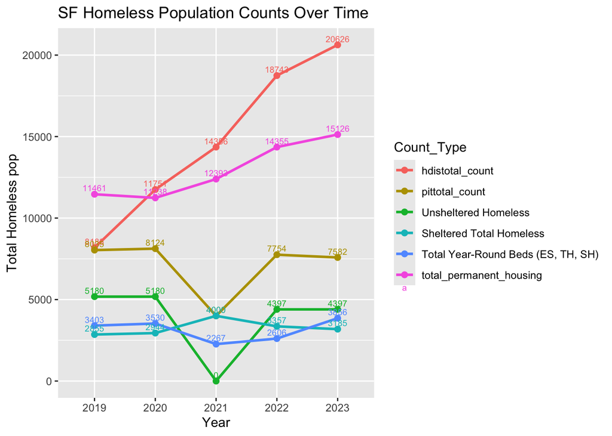

```r
ggplot(longPITandHDIS[longPITandHDIS$LOCATION_ID == "CA-501",], aes(x = factor(year), y = Count, color = Count_Type, group = Count_Type)) +
  geom_line(size = 1) +  # Draw the lines
  geom_point(size = 2) +  # Add points to the lines
  geom_text(aes(label = Count),
            size = 2.5, vjust = -0.5, hjust = 0.5) +  # Add labels to points
  labs(
    x = "Year",
    y = "Total Homeless pop",
    title = "SF Homeless Population Counts Over Time"
  )
```

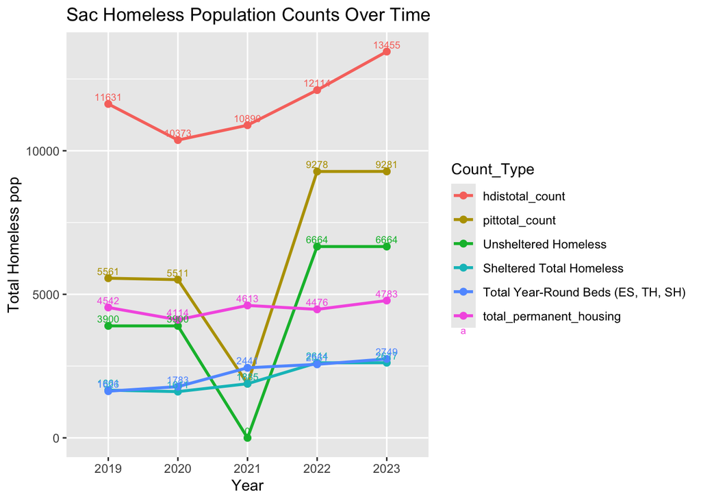

```r
ggplot(longPITandHDIS[longPITandHDIS$LOCATION_ID == "CA-503",], aes(x = factor(year), y = Count, color = Count_Type, group = Count_Type)) +
  geom_line(size = 1) +  # Draw the lines
  geom_point(size = 2) +  # Add points to the lines
  geom_text(aes(label = Count),
            size = 2.5, vjust = -0.5, hjust = 0.5) +  # Add labels to points
  labs(
    x = "Year",
    y = "Total Homeless pop",
    title = "Sac Homeless Population Counts Over Time"
  )
```

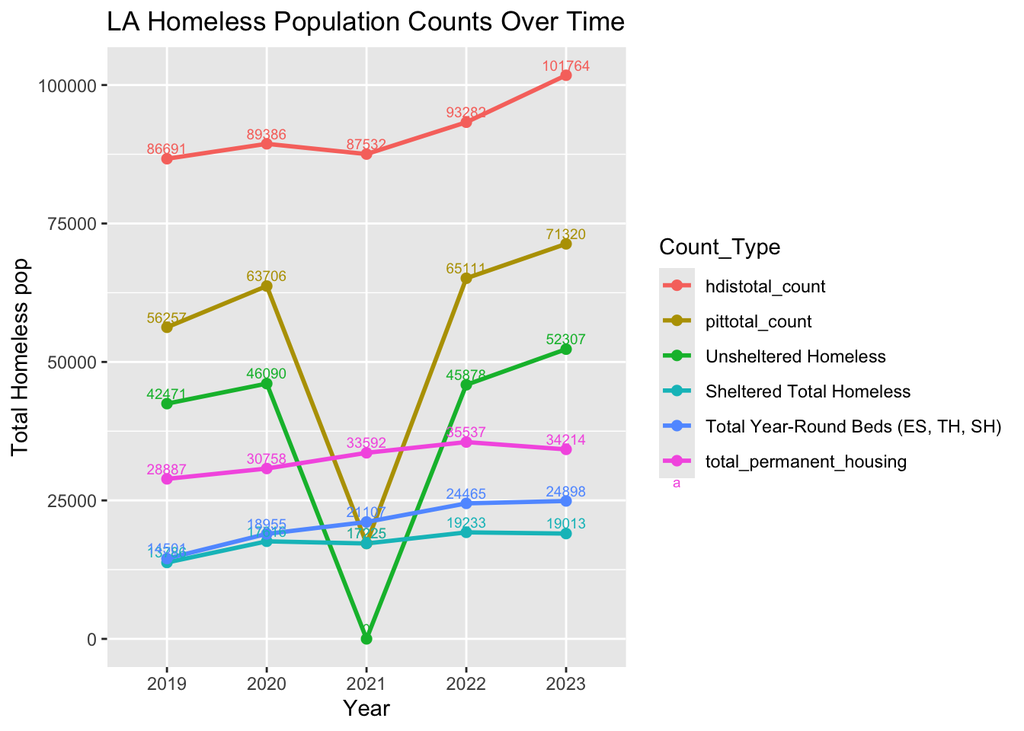

```r
ggplot(longPITandHDIS[longPITandHDIS$LOCATION_ID == "CA-600",], aes(x = factor(year), y = Count, color = Count_Type, group = Count_Type)) +
  geom_line(size = 1) +  # Draw the lines
  geom_point(size = 2) +  # Add points to the lines
  geom_text(aes(label = Count),
            size = 2.5, vjust = -0.5, hjust = 0.5) +  # Add labels to points
  labs(
    x = "Year",
    y = "Total Homeless pop",
    title = "LA Homeless Population Counts Over Time"
  )
```

## Creating a new dataset for comparing changes in variables over time

```r
PITandHDISchange <- PITandHDIS %>%
    group_by(LOCATION_ID) %>%
    filter(year == min(year) | year == max(year)) %>%
    summarise(pit_change = pittotal_count[year == max(year)] - pittotal_count[year == min(year)],
              pit_pct_change = (pittotal_count[year == max(year)] - pittotal_count[year == min(year)])/pittotal_count[year == min(year)],
              sheltered_change = `Sheltered Total Homeless`[year == max(year)] - `Sheltered Total Homeless`[year == min(year)],
              sheltered_pct_change = (`Sheltered Total Homeless`[year == max(year)] - `Sheltered Total Homeless`[year == min(year)])/`Sheltered Total Homeless`[year == min(year)],
              unsheltered_change = `Unsheltered Homeless`[year == max(year)] - `Unsheltered Homeless`[year == min(year)],
              unsheltered_pct_change = (`Unsheltered Homeless`[year == max(year)] - `Unsheltered Homeless`[year == min(year)])/`Unsheltered Homeless`[year == min(year)],
              hdis_change = hdistotal_count[year == max(year)] - hdistotal_count[year == min(year)],
              hdis_pct_change = (hdistotal_count[year == max(year)] - hdistotal_count[year == min(year)])/hdistotal_count[year == min(year)],
              permhousing_change = total_permanent_housing[year == max(year)] - total_permanent_housing[year == min(year)],
              permhousing_pct_change = (total_permanent_housing[year == max(year)] - total_permanent_housing[year == min(year)])/total_permanent_housing[year == min(year)],
              shelter_change = `Total Year-Round Beds (ES, TH, SH)`[year == max(year)] - `Total Year-Round Beds (ES, TH, SH)`[year == min(year)],
              shelter_pct_change = (`Total Year-Round Beds (ES, TH, SH)`[year == max(year)] - `Total Year-Round Beds (ES, TH, SH)`[year == min(year)])/`Total Year-Round Beds (ES, TH, SH)`[year == min(year)],
              COC_Name = `CoC Name`
                  )
PITandHDISchange <- distinct(PITandHDISchange)
```

## Relationships between changes in variables over time

homelessness change as a function of permanent housing change

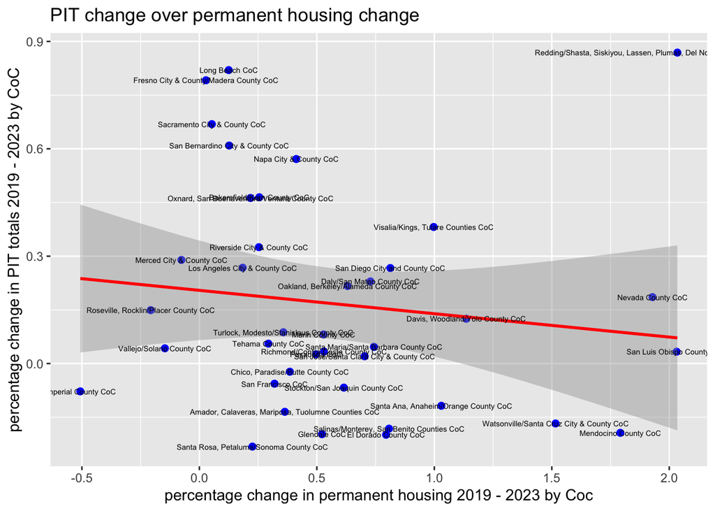

```r
PITandHDISchange[PITandHDISchange$LOCATION_ID != "All",] %>%
    filter(permhousing_pct_change < 5 & permhousing_pct_change > -0.9) %>%
ggplot(aes(x = permhousing_pct_change, y = pit_pct_change)) +
    geom_point(color = "blue", size = 2) +
    geom_smooth(method = "lm", se = TRUE, color = "red") +
    geom_text(aes(label = COC_Name),
              size = 1.9) +
    labs(
        x = "percentage change in permanent housing 2019 - 2023 by Coc",
        y = "percentage change in PIT totals 2019 - 2023 by CoC",
        title = "PIT change over permanent housing change"
    )
```

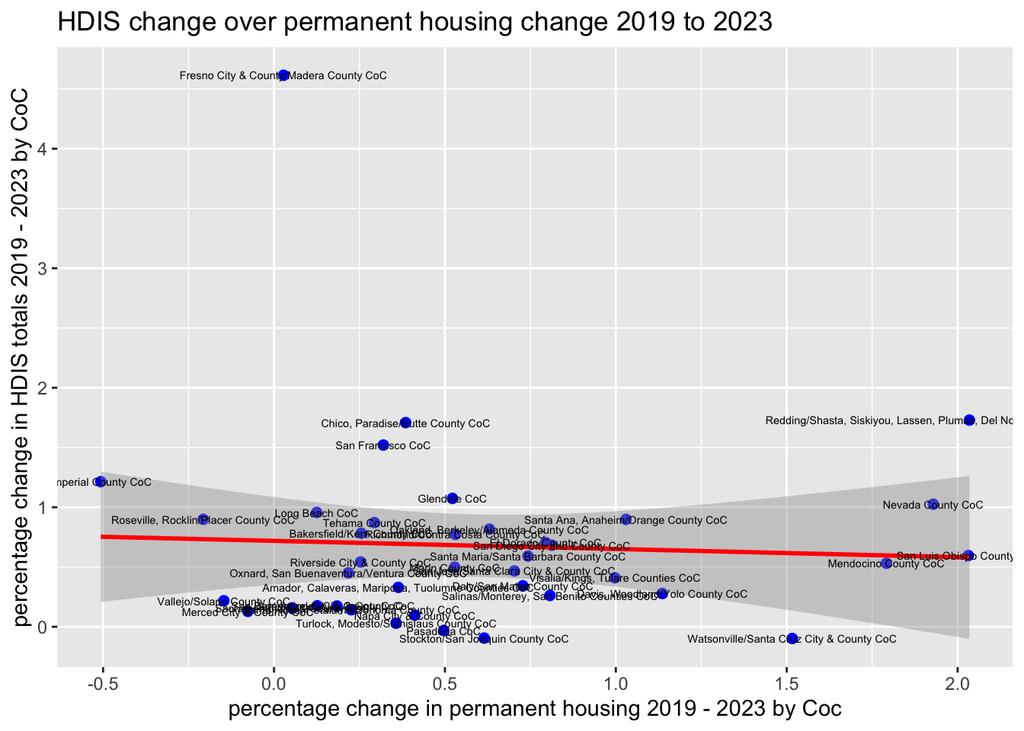

```r
PITandHDISchange[PITandHDISchange$LOCATION_ID != "All",] %>%
    filter(permhousing_pct_change < 5 & permhousing_pct_change > -0.9) %>%
ggplot(aes(x = permhousing_pct_change, y = hdis_pct_change)) +
    geom_point(color = "blue", size = 2) +
    geom_smooth(method = "lm", se = TRUE, color = "red") +
    geom_text(aes(label = COC_Name),
              size = 1.9) +
    labs(
        x = "percentage change in permanent housing 2019 - 2023 by Coc",
        y = "percentage change in HDIS totals 2019 - 2023 by CoC",
        title = "HDIS change over permanent housing change 2019 to 2023"
    )
```

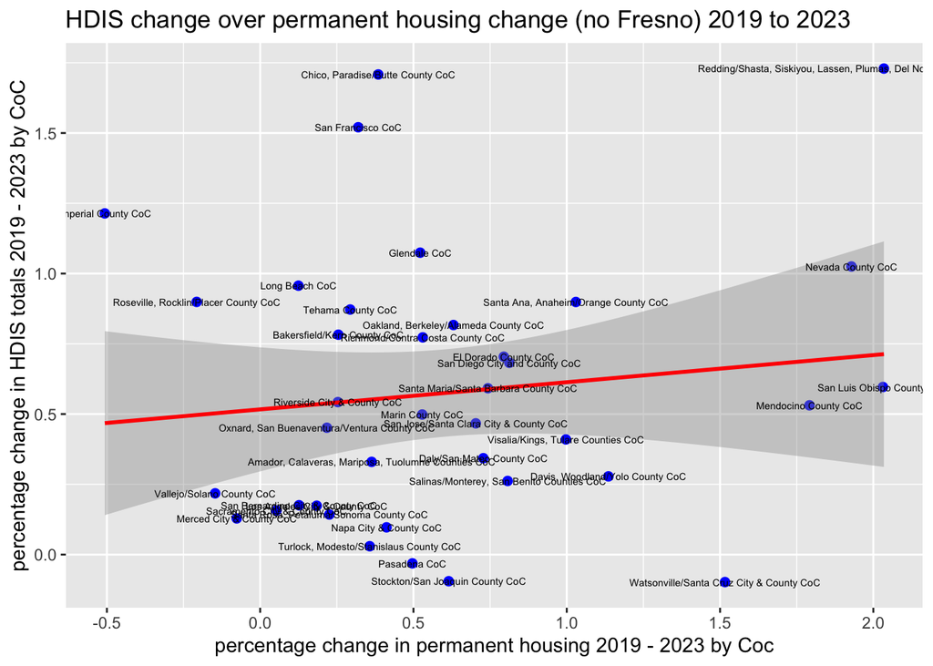

```r
PITandHDISchange[PITandHDISchange$LOCATION_ID != c("All", "CA-514"),] %>%
    filter(permhousing_pct_change < 5 & permhousing_pct_change > -0.9) %>%
ggplot(aes(x = permhousing_pct_change, y = hdis_pct_change)) +
    geom_point(color = "blue", size = 2) +
    geom_smooth(method = "lm", se = TRUE, color = "red") +
    geom_text(aes(label = COC_Name),
              size = 1.9) +
    labs(
        x = "percentage change in permanent housing 2019 - 2023 by Coc",
        y = "percentage change in HDIS totals 2019 - 2023 by CoC",
        title = "HDIS change over permanent housing change (no Fresno) 2019 to 2023"
    )
```

homelessness change as a function of Fair Market Rent (FMR) change

```r
countyname_vector <- c("NA", "Santa Clara County", "San Francisco County", "Alameda County", "Sacramento County", "Sonoma County", "Contra Costa County", "NA", "Marin County", "Santa Cruz County", "Mendocino County", "Stanislaus County", "San Joaquin County", "San Mateo County", "NA", "NA", "Placer County", "NA", "Napa County", "Solano County","Butte County", "Merced County", "Yolo County", "Humboldt County", "NA", "NA", "El Dorado County", "NA", "Tehama County", "Lake County", "NA", "Nevada County", "Los Angeles County", "San Diego County", "Orange County", "Santa Barbara County", "Kern County", "NA", "NA", "Riverside County", "San Bernadino", "Ventura County", "NA", "Imperial County", "San Luis Obispo")
PITandHDISchange$countyname <- countyname_vector

FMR_Data <- read_excel("change in FMR 2019 to 2023.xlsx")

PITandHDISchange <- PITandHDISchange %>%
    left_join(FMR_Data, by = "countyname")
```

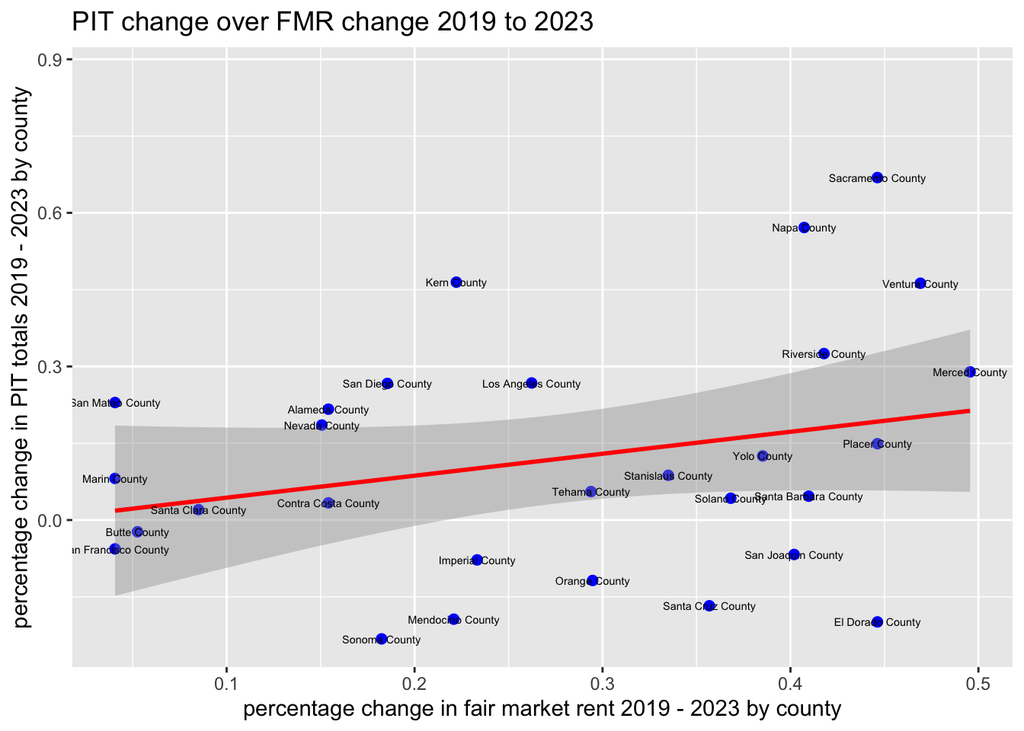

```r
PITandHDISchange[PITandHDISchange$LOCATION_ID != "All",] %>%
    filter(permhousing_pct_change < 5 & permhousing_pct_change > -0.9) %>%
ggplot(aes(x = FMR_pct_change, y = pit_pct_change)) +
    geom_point(color = "blue", size = 2) +
    geom_smooth(method = "lm", se = TRUE, color = "red") +
    geom_text(aes(label = countyname),
              size = 1.9) +
    labs(
        x = "percentage change in fair market rent 2019 - 2023 by county",
        y = "percentage change in PIT totals 2019 - 2023 by county",
        title = "PIT change over FMR change 2019 to 2023"
    )
```

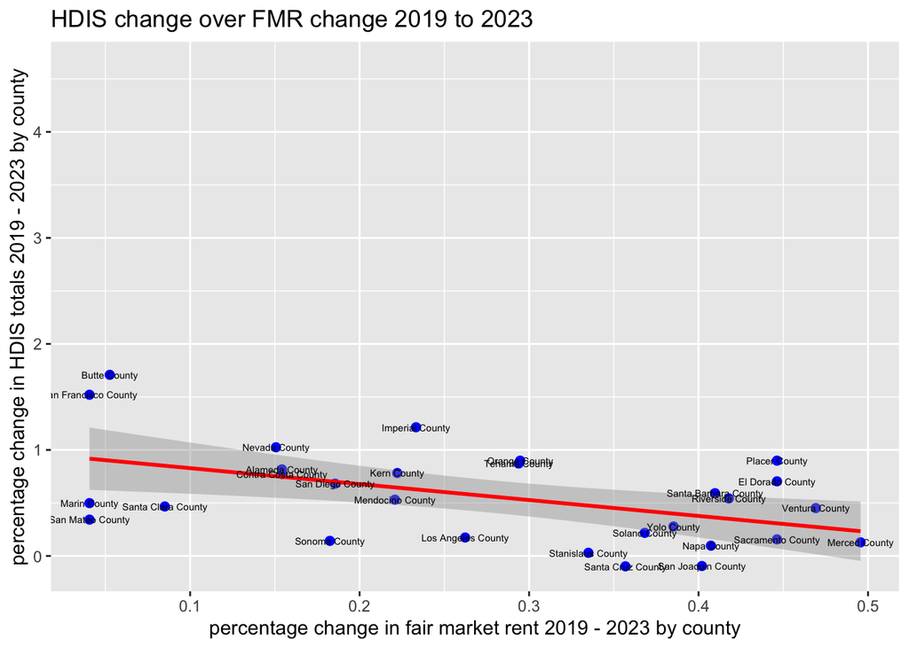

```r
PITandHDISchange[PITandHDISchange$LOCATION_ID != "All",] %>%
    filter(permhousing_pct_change < 5 & permhousing_pct_change > -0.9) %>%
ggplot(aes(x = FMR_pct_change, y = hdis_pct_change)) +
    geom_point(color = "blue", size = 2) +
    geom_smooth(method = "lm", se = TRUE, color = "red") +
    geom_text(aes(label = countyname),
              size = 1.9) +
    labs(
        x = "percentage change in fair market rent 2019 - 2023 by county",
        y = "percentage change in HDIS totals 2019 - 2023 by county",
        title = "HDIS change over FMR change 2019 to 2023"
    )
```

## Are PIT and HDIS counts even comparable?

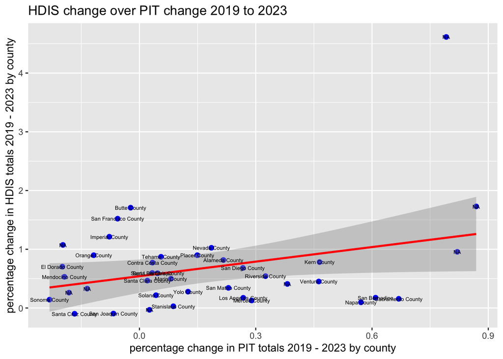

```r
PITandHDISchange[PITandHDISchange$LOCATION_ID != "All",] %>%
    filter(permhousing_pct_change < 5 & permhousing_pct_change > -0.9) %>%
ggplot(aes(x = pit_pct_change, y = hdis_pct_change)) +
    geom_point(color = "blue", size = 2) +
    geom_smooth(method = "lm", se = TRUE, color = "red") +
    geom_text(aes(label = countyname),
              size = 1.9) +
    labs(
        x = "percentage change in PIT totals 2019 - 2023 by county",
        y = "percentage change in HDIS totals 2019 - 2023 by county",
        title = "HDIS change over PIT change 2019 to 2023"
    )
```